# LogisticRegression

Manpreet S. Katari

## Introduction

Logistic regression is a form of machine learning where a generalized linear model can be created using a training set and then tested using another dataset. Logistic regression method is very similar to linear regression but the output variable is binary instead of continuous and the variance does not have to be equal. In this example we will use a breast cancer dataset containing 15,000 observations (patients) to create a model which can be used to predict the output variable, in this case whether the patient will die. The output variable is alivestatus and the input variables are nodespos (number of positive nodes, size size of the tumor, and grade tumor grade. Tumor cells are classiﬁed into 4 diﬀerent grades:

- Grade 1) low-grade: cells are well diﬀerentiated.
- Grade 2) intermediate-grade: moderately well diﬀerentiated,
- Grade 3) poorly diﬀerentiated and
- Grade 4) undiﬀerentiated.

Grades 3 and 4 are generally associated with poor prognosis.

Example data and scripts in this exercise are taken from [1].

## Analysis

### Loading the data

First make sure working directory is set correctly. Then read the ﬁle into the variable called data.10yr.

```r
read.table("all.15k.patients.txt", header=T, row.names=1)->data.10yr
```

```r
head(data.10yr)
```

```
##          dateofbirth maritalstatus race ageatdiagnosis alivestatus survivaltime
## pid00001  28/01/1932             5    2             61           0          110
## pid00002  07/05/1934             2    3             60           0          100
## pid00003  14/04/1921             5    3             76           0           70
## pid00004  08/11/1931             3    3             61           1           31
## pid00005  08/01/1922             2    3             74           1           47
## pid00006  03/12/1939             2    3             55           0          100
##          grade nodesexam nodespos extent nodalstatus size pgr er
## pid00001     3        32        3     10           6   60   2  2
## pid00002     2        13        1     10           6   15   1  1
## pid00003     3         8        0     10           0    8   1  1
## pid00004     3        20        0     10           0   10   2  2
## pid00005     2        16        8     10           6   15   2  1
## pid00006     3        19        0     10           0   48   1  1
```

```r
summary(data.10yr)
```

```
##  dateofbirth        maritalstatus        race       ageatdiagnosis
##  Length:15000       Min.   :1.000   Min.   :1.000   Min.   :22.0
##  Class :character   1st Qu.:2.000   1st Qu.:2.000   1st Qu.:47.0
##  Mode  :character   Median :2.000   Median :2.000   Median :58.0
##                     Mean   :2.617   Mean   :2.088   Mean   :57.7
##                     3rd Qu.:3.000   3rd Qu.:2.000   3rd Qu.:68.0
##                     Max.   :5.000   Max.   :3.000   Max.   :97.0
##   alivestatus      survivaltime        grade         nodesexam
##  Min.   :0.0000   Min.   :  0.00   Min.   :1.000   Min.   : 1.00
##  1st Qu.:0.0000   1st Qu.: 80.00   1st Qu.:2.000   1st Qu.:11.00
##  Median :0.0000   Median :104.00   Median :2.000   Median :15.00
##  Mean   :0.1837   Mean   : 99.06   Mean   :2.305   Mean   :15.77
##  3rd Qu.:0.0000   3rd Qu.:126.00   3rd Qu.:3.000   3rd Qu.:20.00
##  Max.   :1.0000   Max.   :155.00   Max.   :4.000   Max.   :90.00
##     nodespos          extent       nodalstatus         size
##  Min.   : 0.000   Min.   :10.00   Min.   :0.000   Min.   :  1.00
##  1st Qu.: 0.000   1st Qu.:10.00   1st Qu.:0.000   1st Qu.: 11.00
##  Median : 0.000   Median :10.00   Median :0.000   Median : 17.00
##  Mean   : 1.668   Mean   :11.17   Mean   :1.786   Mean   : 21.21
##  3rd Qu.: 1.000   3rd Qu.:10.00   3rd Qu.:6.000   3rd Qu.: 25.00
##  Max.   :97.000   Max.   :70.00   Max.   :9.000   Max.   :200.00
##       pgr              er
##  Min.   :1.000   Min.   :1.000
##  1st Qu.:1.000   1st Qu.:1.000
##  Median :1.000   Median :1.000
##  Mean   :1.371   Mean   :1.292
##  3rd Qu.:2.000   3rd Qu.:2.000
##  Max.   :3.000   Max.   :3.000
```

Notice that due to the coding of some of the variables, some of the columns were not loaded in the correct mode. make sure the columns are of the correct mode.

```r
data.10yr[,"alivestatus"] = as.factor(data.10yr[,"alivestatus"])
data.10yr[,"grade"] = as.numeric(data.10yr[,"grade"])
data.10yr[,"nodespos"] = as.numeric(data.10yr[,"nodespos"])
data.10yr[,"size"] = as.numeric(data.10yr[,"size"])
```

### Performing Logistic Regression

Creating a logistic regression model is very similar to creating a linear regression model. Setting the parameter “family” to “binomial”tells the **glm()** function to create a logistic regression model.

```r
lr.glm = glm(alivestatus ~ size + nodespos + grade,
             data = data.10yr,
             family="binomial")

summary(lr.glm)
```

```
##
## Call:
## glm(formula = alivestatus ~ size + nodespos + grade, family = "binomial",
##     data = data.10yr)
##
## Deviance Residuals:
##     Min       1Q   Median       3Q      Max
## -5.0612  -0.6022  -0.4451  -0.3164   2.5375
##
## Coefficients:
##              Estimate Std. Error z value Pr(>|z|)
## (Intercept) -3.899557   0.095006  -41.05   <2e-16 ***
## size         0.023213   0.001391   16.69   <2e-16 ***
## nodespos     0.149229   0.005960   25.04   <2e-16 ***
## grade        0.628004   0.035757   17.56   <2e-16 ***
## ---
## Signif. codes:  0 '***' 0.001 '**' 0.01 '*' 0.05 '.' 0.1 ' ' 1
##
## (Dispersion parameter for binomial family taken to be 1)
##
##     Null deviance: 14307  on 14999  degrees of freedom
## Residual deviance: 12094  on 14996  degrees of freedom
## AIC: 12102
##
## Number of Fisher Scoring iterations: 5
```

Note that the summary output of logistic regression model is very similar to that of linear regression.

The **predict()** function can be used to determine the probability of getting the value 1. The parameter “type” speciﬁes which results to return. In order to retrieve the predicted probability of the outcome “1” ( 1 in the output variable alivestatus means death. ) use “response”.

```r
pr<-predict(lr.glm, newdata=data.10yr, type="response")
```

From the prediction results, a probability greater than 0.5 will most likely be dead (have a value of 1). Using this cutoﬀ, a predicted result vector can be created names pr.perf which can be compared to the actual result. In order to compare the predicted with actual results there are certain terminologies that are important to understand:

- TP: True positive: Predictions of TRUE event and it is actually TRUE
- TN: True negative: Prediction of FALSE event and it is actually FALSE.
- FP: False positive: Prediction of TRUE even, but it is actually FALSE.
- FN: False negative: Prediction of FALSE even and it is TRUE

These numbers in combination can provide useful statistics to judge the quality of the model.

- accuracy: total number of correct predictions divided by all possible predictions and events.
- recall: of all actual TRUE events, how many were predicted to be TRUE. Also known as **Sensitivity** and TPR (true positive rate)
- precision: of all predicted TRUE, how many were actually true
- TNR: True negative rate: Of all actual FALSE events, how many were predicted FALSE. Also known as **Specificity**

```r
pr.perf=as.numeric(pr>0.5)

confmat<-table(data.10yr[,"alivestatus"], pr.perf, dnn=c("actual", "predicted"))
confmat
```

```
##       predicted
## actual     0     1
##      0 11928   317
##      1  2203   552
```

```r
TP=confmat["1","1"]
TN=confmat["0","0"]
FP=confmat["0","1"]
FN=confmat["1","0"]

accuracy = (TP+TN)/(TP+TN+FP+FN)
accuracy
```

```
## [1] 0.832
```

```r
recall = TP/(TP+FN)
recall
```

```
## [1] 0.200363
```

```r
precision = TP/(TP+FP)
precision
```

```
## [1] 0.6352129
```

```r
TNR = TN/(TN+FP)
TNR
```

```
## [1] 0.9741119
```

### AUC

```r
#install.packages("pROC")
library(pROC)
ndf = data.frame(response = data.10yr$alivestatus,
                 prob = pr)
data_proc = roc(data = ndf,
                response="response",
                predictor = "prob")
proc_df = data.frame(cutoff=data_proc$thresholds,
                     sensitivity=data_proc$sensitivities,
                     specificity=data_proc$specificities)

subset(proc_df, cutoff>0.499 & cutoff < 0.501)
```

```
##         cutoff sensitivity specificity
## 1055 0.4990265    0.200363   0.9740302
## 1056 0.5005774    0.200363   0.9741119
```

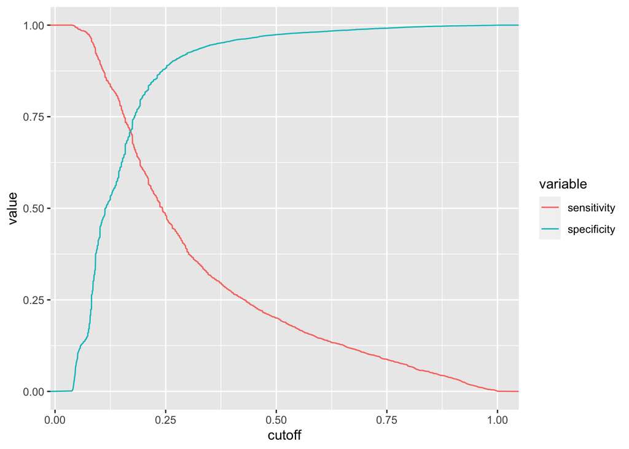

```r
library(reshape2)
proc_df_melt = melt(proc_df,id.vars=c("cutoff"),
                    measure.vars=c("sensitivity","specificity"))

library(ggplot2)
ggplot(proc_df_melt) + geom_line(mapping=aes(x=cutoff, y=value, color=variable))
```

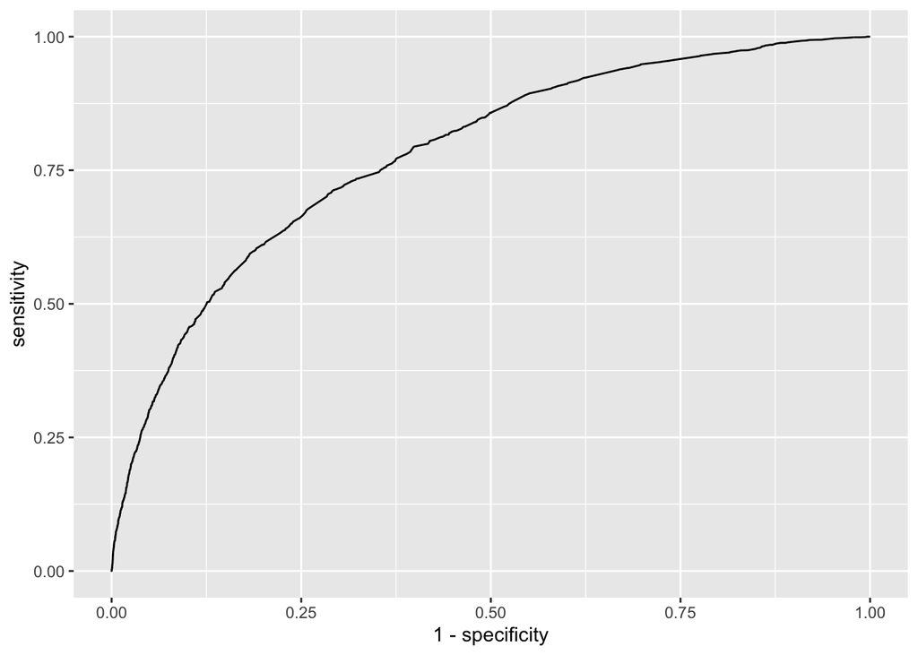

```r
ggplot(proc_df) + geom_line(mapping=aes(x=1-specificity, y=sensitivity))
```

```r
auc(data_proc)
```

```
## Area under the curve: 0.7809
```

### Holdout method

```r
split<-sample(nrow(data.10yr), floor(nrow(data.10yr) * 0.7))
split.train<-data.10yr[split,]
split.test<-data.10yr[-split,]
lr.split<-glm(formula = alivestatus ~ size + nodespos + grade,
              family="binomial",
              data=split.train)
pr.split<-predict(lr.split, newdata=split.test, type="response")

ndf = data.frame(response = split.test$alivestatus,
                 prob = pr.split)
data_proc = roc(data = ndf,
                response="response",
                predictor = "prob")
auc(data_proc)
```

```
## Area under the curve: 0.7869
```

### Balancing the dataset

A quick inspection of the data reveals that the dataset is quite unbalanced. This can create a bias in the model by putting more weight on the population that is better represented, in this case Alive. In order to balance the dataset simply select equal number of patients, randomly, from both alivestatus levels.

```r
table(data.10yr[,"alivestatus"])
```

```
##
##     0     1
## 12245  2755
```

```r
allAlive<-data.10yr[which(data.10yr[,"alivestatus"] == 0),]
allDead<-data.10yr[which(data.10yr[,"alivestatus"] == 1),]
sample(1:nrow(allAlive), nrow(allDead))->rand.0
allAlive[rand.0,]->alive
allDead->dead
```

#### Holdout method with Reduced Dataset

```r
training.split<-rbind(alive, dead)
split<-sample(nrow(training.split), floor(nrow(training.split) * 0.7))
split.train<-training.split[split,]
split.test<-training.split[-split,]
lr.split<-glm(formula = alivestatus ~ size + nodespos + grade,
              family="binomial",
              data=split.train)

pr.split<-predict(lr.split, newdata=split.test, type="response")

ndf = data.frame(response = split.test$alivestatus,
                 prob = pr.split)
data_proc = roc(data = ndf,
                response="response",
                predictor = "prob")
auc(data_proc)
```

```
## Area under the curve: 0.7906
```

### K-fold cross-validation

A more robust method of holdout is to use K-fold cross-validation . In this method the data is split into 10 parts (K=10) where 9/10 parts are used for training and the other 1 is used for testing. The method does this 10 times for all 10 parts and comes up with a performance score. The DAAG package provides a simple interface for K-fold cross-validation. CVbinary performs a cross-validation of the model and return the accuracy of the model.

```r
install.packages("DAAG")
```

```r
lr.fold<-glm(formula = alivestatus ~ size + nodespos + grade,
             family="binomial",
             data=data.10yr)
library("DAAG")
CVbinary(lr.fold)
```

```
##
## Fold:  5 4 2 1 3 8 9 10 6 7
## Internal estimate of accuracy = 0.832
## Cross-validation estimate of accuracy = 0.832
```